# Problem Statement

AllLife Bank wants to focus on its credit card customer base in the next financial year. They have been advised by their marketing research team, that the penetration in the market can be improved. Based on this input, the Marketing team proposes to run personalised campaigns to target new customers as well as upsell to existing customers. Another insight from the market research was that the customers perceive the support services of the back poorly. Based on this, the Operations team wants to upgrade the service delivery model, to ensure that customers queries are resolved faster. Head of Marketing and Head of Delivery both decide to reach out to the Data Science team for help.

## Objective:

To identify different segments in the existing customer based on their spending patterns as well as past interaction with the bank.

## Key Questions:

1. How many different segments of customers are there?
2. How are these segments different from each other?
3. What are your recommendations to the bank on how to better market to and service these customers?

## Data Description:

- Data is of various customers of a bank with their credit limit, the total number of credit cards the customer has, and different channels through which customer has contacted the bank for any queries, different channels include visiting the bank, online and through a call centre.

```python
import warnings
import numpy as np
import pandas as pd
from sklearn.cluster import KMeans
from yellowbrick.cluster import KElbowVisualizer, SilhouetteVisualizer
import seaborn as sns
import matplotlib.pyplot as plt
from scipy.spatial.distance import cdist
from scipy.stats import zscore
from scipy.spatial.distance import pdist
from scipy.cluster.hierarchy import dendrogram, linkage,cophenet
from sklearn.metrics import silhouette_score
from sklearn.cluster import AgglomerativeClustering
#sns.set_theme(style='darkgrid')
%matplotlib inline
warnings.filterwarnings('ignore')
```

```python
df = pd.read_csv('Credit Card Customer Data.csv').dropna()
```

**Exploratory Data Analysis**

```python
df.shape
```

```
(660, 7)
```

```python
df.info()
```

```
<class 'pandas.core.frame.DataFrame'>
Int64Index: 660 entries, 0 to 659
Data columns (total 7 columns):
 #   Column               Non-Null Count  Dtype
---  ------               --------------  -----
 0   Sl_No                660 non-null    int64
 1   Customer Key         660 non-null    int64
 2   Avg_Credit_Limit     660 non-null    int64
 3   Total_Credit_Cards   660 non-null    int64
 4   Total_visits_bank    660 non-null    int64
 5   Total_visits_online  660 non-null    int64
 6   Total_calls_made     660 non-null    int64
dtypes: int64(7)
memory usage: 41.2 KB
```

```python
df.head()
```

|  | Sl_No | Customer Key | Avg_Credit_Limit | Total_Credit_Cards | Total_visits_bank | Total_visits_online | Total_calls_made |
| --- | --- | --- | --- | --- | --- | --- | --- |
| 0 | 1 | 87073 | 100000 | 2 | 1 | 1 | 0 |
| 1 | 2 | 38414 | 50000 | 3 | 0 | 10 | 9 |
| 2 | 3 | 17341 | 50000 | 7 | 1 | 3 | 4 |
| 3 | 4 | 40496 | 30000 | 5 | 1 | 1 | 4 |
| 4 | 5 | 47437 | 100000 | 6 | 0 | 12 | 3 |

```python
df.describe().T
```

|  | count | mean | std | min | 25% | 50% | 75% | max |
| --- | --- | --- | --- | --- | --- | --- | --- | --- |
| Sl_No | 660.0 | 330.500000 | 190.669872 | 1.0 | 165.75 | 330.5 | 495.25 | 660.0 |
| Customer Key | 660.0 | 55141.443939 | 25627.772200 | 11265.0 | 33825.25 | 53874.5 | 77202.50 | 99843.0 |
| Avg_Credit_Limit | 660.0 | 34574.242424 | 37625.487804 | 3000.0 | 10000.00 | 18000.0 | 48000.00 | 200000.0 |
| Total_Credit_Cards | 660.0 | 4.706061 | 2.167835 | 1.0 | 3.00 | 5.0 | 6.00 | 10.0 |
| Total_visits_bank | 660.0 | 2.403030 | 1.631813 | 0.0 | 1.00 | 2.0 | 4.00 | 5.0 |
| Total_visits_online | 660.0 | 2.606061 | 2.935724 | 0.0 | 1.00 | 2.0 | 4.00 | 15.0 |
| Total_calls_made | 660.0 | 3.583333 | 2.865317 | 0.0 | 1.00 | 3.0 | 5.00 | 10.0 |

**Univariate Analysis**

### KDE plot for all the features to see how many of it can show separate clusters.

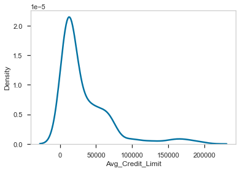

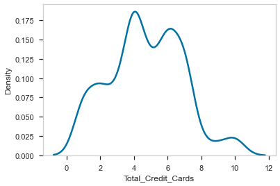

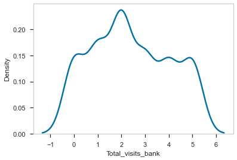

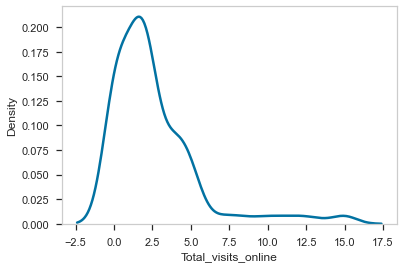

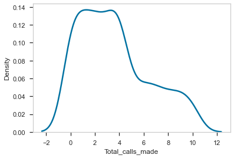

```python
cols=['Avg_Credit_Limit','Total_Credit_Cards','Total_visits_bank','Total_visits_online','Total_calls_made']
for i in cols:
    sns.distplot(df[i],hist=False,)
    plt.show()
```

### Box Plot

[figure not shown]

```python
# selecting numerical columns
all_col = df.select_dtypes(include=np.number).columns.tolist()

fig, axes = plt.subplots(3, 2,  figsize=(20, 15))
fig.suptitle('Boxplot of numerical variables', fontsize=20)
counter = 0
for ii in range(3):
    sns.boxplot(ax=axes[ii][0],x=df[cols[counter]])
    counter = counter+1
    if counter != 5:
        sns.boxplot(ax=axes[ii][1],x=df[cols[counter]])
        counter = counter+1
    else:
        pass

fig.tight_layout(pad=2.0)
```

## Histogram

[figure not shown]

```python
# select numerical columns
all_col = df.select_dtypes(include=np.number).columns.tolist()

fig, axes = plt.subplots(3, 2,  figsize=(20, 15))
fig.suptitle('Histogram of numerical variables', fontsize=20)
counter = 0
for ii in range(3):
    sns.histplot(ax=axes[ii][0],x=df[cols[counter]])
    counter = counter+1
    if counter != 5:
        sns.histplot(ax=axes[ii][1],x=df[cols[counter]])
        counter = counter+1
    else:
        pass

fig.tight_layout(pad=2.0)
```

## Cumulative Distribution Function (CDF) plot

[figure not shown]

```python
# select numerical columns
all_col = df.select_dtypes(include=np.number).columns.tolist()

fig, axes = plt.subplots(3, 2,  figsize=(20, 15))
fig.suptitle('CDF plot of numerical variables', fontsize=20)
counter = 0
for ii in range(3):
    sns.ecdfplot(ax=axes[ii][0],x=df[cols[counter]])
    counter = counter+1
    if counter != 5:
        sns.ecdfplot(ax=axes[ii][1],x=df[cols[counter]])
        counter = counter+1
    else:
        pass


fig.tight_layout(pad=2.0)
```

## Bar plots

```python
# Function to create barplots that indicate percentage for each category.

def perc_on_bar(z):
    '''
    plot
    feature: categorical feature
    the function won't work if a column is passed in hue parameter
    '''

    total = len(df[z]) # length of the column
    plt.figure(figsize=(15,5))
    ax = sns.countplot(df[z],palette='Paired')
    for p in ax.patches:
        percentage = '{:.1f}%'.format(100 * p.get_height()/total) # percentage of each class of the category
        x = p.get_x() + p.get_width() / 2 - 0.05 # width of the plot
        y = p.get_y() + p.get_height()           # hieght of the plot

        ax.annotate(percentage, (x, y), size = 12) # annotate the percantage
    plt.show() # show the plot
```

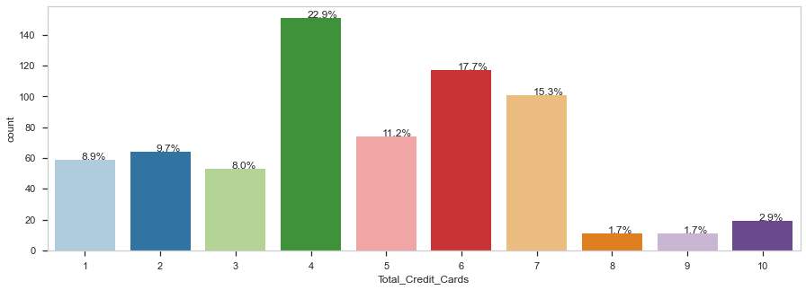

```python
perc_on_bar('Total_Credit_Cards')
```

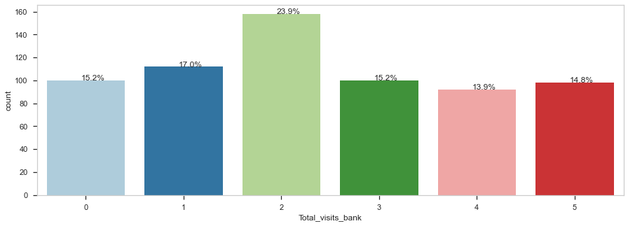

```python
perc_on_bar('Total_visits_bank')
```

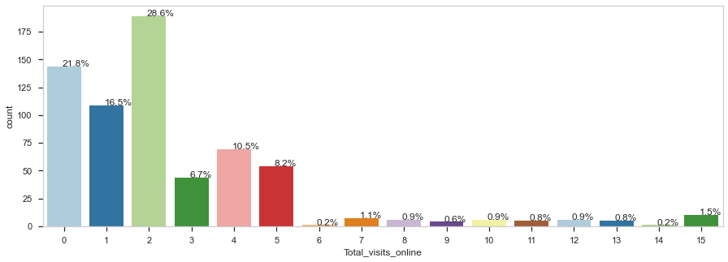

```python
perc_on_bar('Total_visits_online')
```

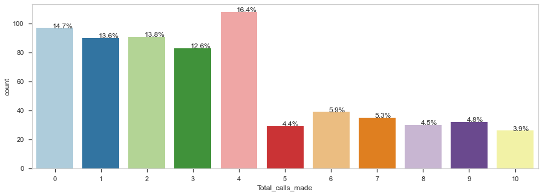

```python
perc_on_bar('Total_calls_made')
```

**Bivariate Analysis**

### Pair Plot

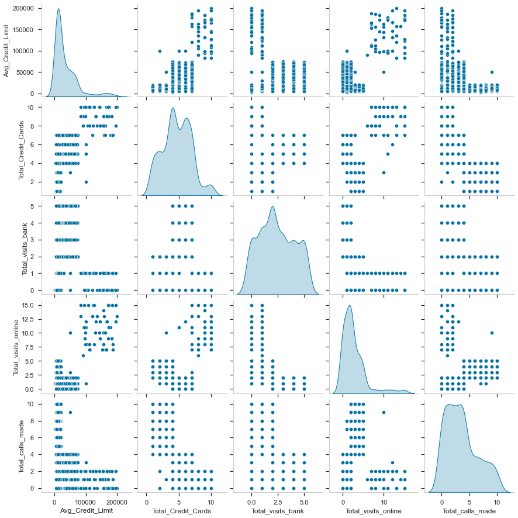

```python
sns.pairplot(df,x_vars=['Avg_Credit_Limit','Total_Credit_Cards','Total_visits_bank','Total_visits_online','Total_calls_made'],
 y_vars=['Avg_Credit_Limit','Total_Credit_Cards','Total_visits_bank','Total_visits_online','Total_calls_made'] ,kind='scatter',diag_kind='kde'
)
plt.show()
```

### Heatmap

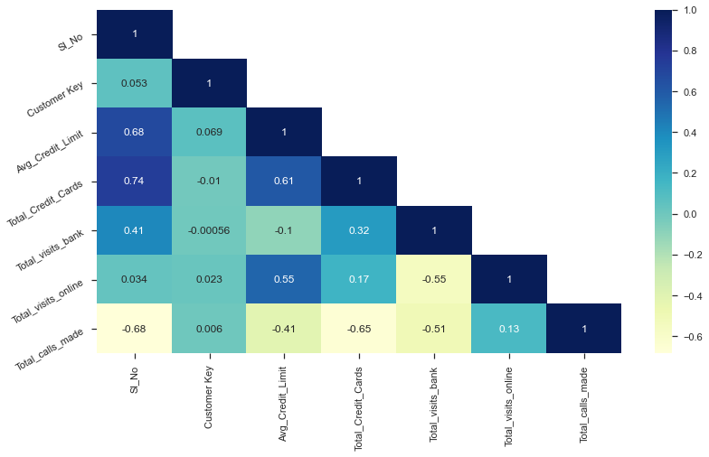

```python
corr = df.corr()
sns.set_context("notebook", font_scale=1.0, rc={"lines.linewidth": 2.5})
plt.figure(figsize=(13,7))
# create a mask so we only see the correlation values once
mask = np.zeros_like(corr)
mask[np.triu_indices_from(mask, 1)] = True
a = sns.heatmap(corr,mask=mask, annot=True,cmap="YlGnBu")
rotx = a.set_xticklabels(a.get_xticklabels(), rotation=90)
roty = a.set_yticklabels(a.get_yticklabels(), rotation=30)
```

**Data pre-processing**

### Check the percentage of missing values in each column

```python
pd.DataFrame(data={'% of Missing Values':round(df.isnull().sum()/df.isnull().count()*100,2)}).sort_values(by='% of Missing Values',ascending=False)
```

|  | % of Missing Values |
| --- | --- |
| Sl_No | 0.0 |
| Customer Key | 0.0 |
| Avg_Credit_Limit | 0.0 |
| Total_Credit_Cards | 0.0 |
| Total_visits_bank | 0.0 |
| Total_visits_online | 0.0 |
| Total_calls_made | 0.0 |

There are no missing values so no special treatment needs to be given

### Finding out value_count for each distinct values in various fields

```python
#since there were many credit limits it was showing .. so putting them into bins for clarity
df['Avg_Credit_Limit'].value_counts(bins=10).sort_index()
```

```
(2802.999, 22700.0]     390
(22700.0, 42400.0]       84
(42400.0, 62100.0]       77
(62100.0, 81800.0]       58
(81800.0, 101500.0]      12
(101500.0, 121200.0]      6
(121200.0, 140900.0]      6
(140900.0, 160600.0]      9
(160600.0, 180300.0]     11
(180300.0, 200000.0]      7
Name: Avg_Credit_Limit, dtype: int64
```

There seems to be around 7 outliers with credit limit above 180300.0 so lets drop them

```python
df.drop(df[df['Avg_Credit_Limit']>180300.0].index, inplace = True)
```

```python
for column in ['Total_Credit_Cards','Total_visits_bank','Total_visits_online','Total_calls_made']:
    print(df[column].value_counts().sort_index())
    print('-'*30)
```

```
1      59
2      64
3      53
4     151
5      74
6     117
7      98
8      10
9      10
10     17
Name: Total_Credit_Cards, dtype: int64
------------------------------
0     96
1    109
2    158
```

[output cut: 36 more lines]

### Lets see how many Unique values are there

```python
df.nunique()
```

```
Sl_No                  653
Customer Key           649
Avg_Credit_Limit       104
Total_Credit_Cards      10
Total_visits_bank        6
Total_visits_online     16
Total_calls_made        11
dtype: int64
```

```python
df.drop(['Sl_No'],axis=1,inplace=True)
df.drop(['Customer Key'],axis=1,inplace=True)
```

### Lets see how many duplicates are there

```python
df[df.duplicated()]
```

|  | Avg_Credit_Limit | Total_Credit_Cards | Total_visits_bank | Total_visits_online | Total_calls_made |
| --- | --- | --- | --- | --- | --- |
| 162 | 8000 | 2 | 0 | 3 | 4 |
| 175 | 6000 | 1 | 0 | 2 | 5 |
| 215 | 8000 | 4 | 0 | 4 | 7 |
| 295 | 10000 | 6 | 4 | 2 | 3 |
| 324 | 9000 | 4 | 5 | 0 | 4 |
| 361 | 18000 | 6 | 3 | 1 | 4 |
| 378 | 12000 | 6 | 5 | 2 | 1 |
| 385 | 8000 | 7 | 4 | 2 | 0 |
| 395 | 5000 | 4 | 5 | 0 | 1 |
| 455 | 47000 | 6 | 2 | 0 | 4 |
| 497 | 52000 | 4 | 2 | 1 | 2 |

There are about 11 duplicates so lets delete them

```python
df = df[(~df.duplicated())].copy()
```

### Standardize the data

```python
# Since the dimensions of the data are not really known to us, it would be wise to standardize the data using z scores
# before we go for any clustering methods. Using zscore function to do this
subset_scaled_df = df.apply(zscore)
```

**K-means clustering**

### Figure out right number of cluster using elbow curve

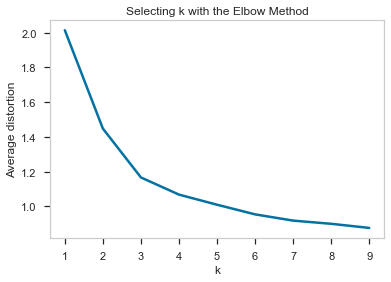

```python
#Finding optimal no. of clusters
clusters=range(1,10)
meanDistortions=[]

for k in clusters:
    model=KMeans(n_clusters=k)
    model.fit(subset_scaled_df)
    prediction=model.predict(subset_scaled_df)
    meanDistortions.append(sum(np.min(cdist(subset_scaled_df, model.cluster_centers_, 'euclidean'), axis=1))
                           / subset_scaled_df.shape[0])


plt.plot(clusters, meanDistortions, 'bx-')
plt.xlabel('k')
plt.ylabel('Average distortion')
plt.title('Selecting k with the Elbow Method')
```

We can see a nice elbow forming around 3. So lets have 3 clusters

### Finding right number of clusters using Silhouette score

```
For n_clusters = 2, silhouette score is 0.4241248152125395)
For n_clusters = 3, silhouette score is 0.5121585124024816)
For n_clusters = 4, silhouette score is 0.35050184324812694)
For n_clusters = 5, silhouette score is 0.33474400231521406)
For n_clusters = 6, silhouette score is 0.2546945875773561)
For n_clusters = 7, silhouette score is 0.2494230745112503)
For n_clusters = 8, silhouette score is 0.23137756204910936)
For n_clusters = 9, silhouette score is 0.22027088646641518)
```

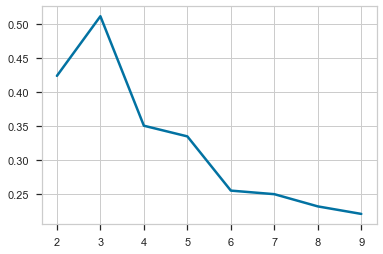

```python
sil_score = []
cluster_list = list(range(2,10))
for n_clusters in cluster_list:
    clusterer = KMeans(n_clusters=n_clusters)
    preds = clusterer.fit_predict((subset_scaled_df))
    #centers = clusterer.cluster_centers_
    score = silhouette_score(subset_scaled_df, preds)
    sil_score.append(score)
    print("For n_clusters = {}, silhouette score is {})".format(n_clusters, score))

plt.plot(cluster_list,sil_score)
plt.grid()
```

We can see 3 clusters are giving the maximum silhouette score. So lets have 3 clusters

### Finding the right number of clusters using SilhouetteVisualizer

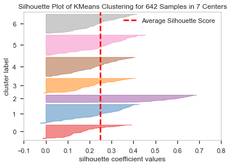

```python
#Finding optimal no. of clusters with silhouette coefficients
visualizer = SilhouetteVisualizer(KMeans(7, random_state = 1))
visualizer.fit(subset_scaled_df)
visualizer.show()
```

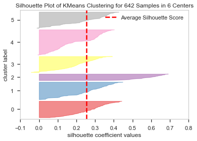

```python
#Finding optimal no. of clusters with silhouette coefficients
visualizer = SilhouetteVisualizer(KMeans(6, random_state = 1))
visualizer.fit(subset_scaled_df)
visualizer.show()
```

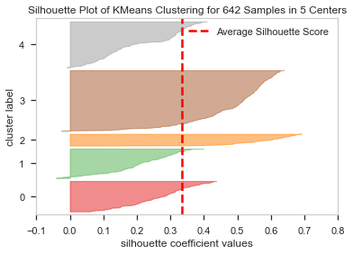

```python
#Finding optimal no. of clusters with silhouette coefficients
visualizer = SilhouetteVisualizer(KMeans(5, random_state = 1))
visualizer.fit(subset_scaled_df)
visualizer.show()
```

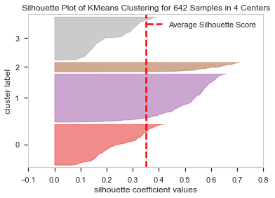

```python
#Finding optimal no. of clusters with silhouette coefficients
visualizer = SilhouetteVisualizer(KMeans(4, random_state = 1))
visualizer.fit(subset_scaled_df)
visualizer.show()
```

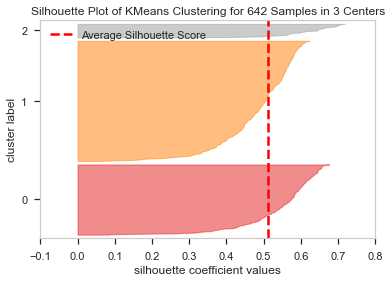

```python
#Finding optimal no. of clusters with silhouette coefficients
visualizer = SilhouetteVisualizer(KMeans(3, random_state = 1))
visualizer.fit(subset_scaled_df)
visualizer.show()
```

n_clusters value of 3 is a good pick for the given data due to the presence of clusters with above average silhouette scores

Elbow curve,silhouette score and silhouette visualizer are all suggesting 3 is the perfect number for clusters

```python
kmeans = KMeans(n_clusters=3, random_state=0)
kmeans.fit(subset_scaled_df)
```

```
KMeans(n_clusters=3, random_state=0)
```

**Data Analysis and Graphs for K means have been added in the end along with Hierarchical clustering for better readability**

**Hierarchical clustering**

## Calculating cophenet index for various Linkage and Distance measuring methods

```python
# cophenet index is a measure of the correlation between the distance of points in feature space and distance on
# dendrogram closer it is to 1, the better is the clustering
distance_metrics = [ 'euclidean','chebyshev','mahalanobis','cityblock']
linkage_methods = ['single', 'complete', 'average', 'weighted']
high_cophenet_corr = 0
high_dm_lm = [0,0]
for dm in distance_metrics:
    for lm in linkage_methods:
        Z = linkage(subset_scaled_df, metric=dm, method=lm)
        c, coph_dists = cophenet(Z , pdist(subset_scaled_df))
        print('Cophent correlation for distance metrics {} and linkage method {} is {}'.format(dm,lm,c))
        if high_cophenet_corr < c:
            high_cophenet_corr = c
            high_dm_lm[0] = dm
            high_dm_lm[1] = lm
```

```
Cophent correlation for distance metrics euclidean and linkage method single is 0.8940070949214551
Cophent correlation for distance metrics euclidean and linkage method complete is 0.8781621780902267
Cophent correlation for distance metrics euclidean and linkage method average is 0.9084990046949583
Cophent correlation for distance metrics euclidean and linkage method weighted is 0.9001390162880887
Cophent correlation for distance metrics chebyshev and linkage method single is 0.8498597740343488
Cophent correlation for distance metrics chebyshev and linkage method complete is 0.8552264259268416
Cophent correlation for distance metrics chebyshev and linkage method average is 0.9070647822308988
Cophent correlation for distance metrics chebyshev and linkage method weighted is 0.9015674881937494
Cophent correlation for distance metrics mahalanobis and linkage method single is 0.8709513585852954
Cophent correlation for distance metrics mahalanobis and linkage method complete is 0.6592734773408837
Cophent correlation for distance metrics mahalanobis and linkage method average is 0.8367581084064956
Cophent correlation for distance metrics mahalanobis and linkage method weighted is 0.8445234005280724
Cophent correlation for distance metrics cityblock and linkage method single is 0.8455511059054109
Cophent correlation for distance metrics cityblock and linkage method complete is 0.8856023589691032
Cophent correlation for distance metrics cityblock and linkage method average is 0.9064919812775222
Cophent correlation for distance metrics cityblock and linkage method weighted is 0.8793959839952775
```

```python
print('Highest cophenet correlation is {}, which is obtinaed with {} distance metric and {} linkage method'.format(high_cophenet_corr ,high_dm_lm[0],high_dm_lm[1]))
```

```
Highest cophenet correlation is 0.9084990046949583, which is obtinaed with euclidean distance metric and average linkage method
```

```python
linkage_methods = ['single', 'complete', 'average','median','ward', 'weighted']
high_cophenet_corr = 0
high_dm_lm = [0,0]

for lm in linkage_methods:
    Z = linkage(subset_scaled_df, metric='euclidean', method=lm)
    c, coph_dists = cophenet(Z , pdist(subset_scaled_df))
    print('Cophent correlation for distance metrics {} and linkage method {} is {}'.format('euclidean',lm,c))
    if high_cophenet_corr < c:
        high_cophenet_corr = c
        high_dm_lm[0] = dm
        high_dm_lm[1] = lm
print('*'*110)
print('Highest cophenet correlation is {}, which is obtained with {} distance metric and {} linkage method'.format(high_cophenet_corr ,'euclidean',high_dm_lm[1]))
```

```
Cophent correlation for distance metrics euclidean and linkage method single is 0.8940070949214551
Cophent correlation for distance metrics euclidean and linkage method complete is 0.8781621780902267
Cophent correlation for distance metrics euclidean and linkage method average is 0.9084990046949583
Cophent correlation for distance metrics euclidean and linkage method median is 0.8560923117960345
Cophent correlation for distance metrics euclidean and linkage method ward is 0.7462112877810094
Cophent correlation for distance metrics euclidean and linkage method weighted is 0.9001390162880887
Highest cophenet correlation is 0.9084990046949583, which is obtained with euclidean distance metric and average linkage method
```

**Observations**

- we see that cophenet index is maximum with euclidean distance metric and average linkage method.

## Dendrogram of different linkage method

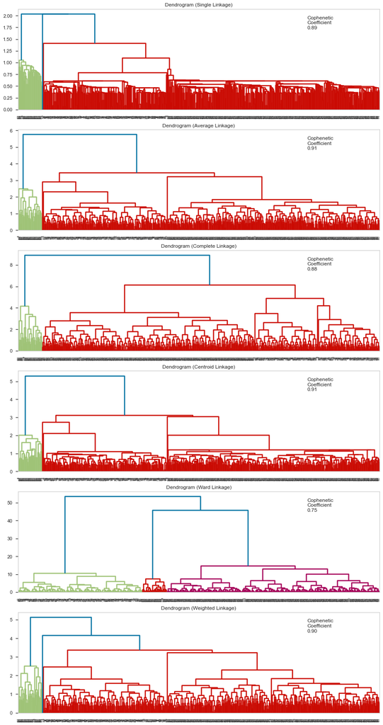

```python
# List of all linkage methods to check
plt.rcParams["axes.grid"] = False
methods = ['single',
           'average',
           'complete',
           'centroid',
           'ward',
           'weighted']

# Calculate the pairwise distance form the dataset to be used in the cophenetic correlation calculation
#pw_distance = pdist(credit_scaled)

# Create lists to save results of coph calculation
compare_cols = ['Linkage', 'Cophenetic Coefficient']
compare = []

# Create a subplot image
fig, axs = plt.subplots(len(methods), 1, figsize=(15, 30))

# Enumerate through the list of all methods above
# Get linkage, plot dendrogram, calculate cophenetic coefficient
for i, method in enumerate(methods):

    Z = linkage(subset_scaled_df, metric='euclidean', method=method)

    dendrogram(Z, ax=axs[i]);
    axs[i].set_title(f'Dendrogram ({method.capitalize()} Linkage)')
    coph_corr, coph_dist = cophenet(Z, pdist(subset_scaled_df))
    axs[i].annotate(f'Cophenetic\nCoefficient\n{coph_corr:0.2f}',
                    (0.80, 0.80),
                    xycoords='axes fraction')
    compare.append([method, coph_corr])
```

**Observations**

- Dendrogram with ward linkage method shows distinct and separate cluster

```python
# Create and print dataframe to compare Cophenetic Coefficient for each linkage
df_cc = pd.DataFrame(compare, columns=compare_cols)
df_cc
```

|  | Linkage | Cophenetic Coefficient |
| --- | --- | --- |
| 0 | single | 0.894007 |
| 1 | average | 0.908499 |
| 2 | complete | 0.878162 |
| 3 | centroid | 0.905575 |
| 4 | ward | 0.746211 |
| 5 | weighted | 0.900139 |

- Let us see the dndrogram of 'mahalanobis','cityblock' with 'average','centroid', 'weighted' linkage method as they gave high cophenetic correlation value

```python
distance_metrics = [ 'mahalanobis','cityblock']
linkage_methods = ['average', 'weighted']
```

[figure not shown]

```python
# Create a subplot image
fig, axs = plt.subplots(len(distance_metrics)+len(distance_metrics), 1, figsize=(15, 30))
i=0
for dm in distance_metrics:
    for lm in linkage_methods:
        Z = linkage(subset_scaled_df, metric=dm, method=lm)
        dendrogram(Z,  ax=axs[i]);
        axs[i].set_title('Distance metircs: {}\nLinkage methods: {}'.format(dm,lm))
        coph_corr, coph_dist = cophenet(Z, pdist(subset_scaled_df))
        axs[i].annotate(f'Cophenetic\nCoefficient\n{coph_corr:0.2f}',
                        (0.80, 0.80),
                        xycoords='axes fraction')
        axs[i].set_title('Distance metircs: {}\nLinkage methods: {}'.format(dm,lm))
        i +=1
```

**Observations**

- Out of all the dendrogram we saw, it is clear that dendrogram with ward linkage method gave us separate and distinct clusters
- 3 cluster would be appropriate number of cluster from dendrogram with ward linkage method

## Let us create 3 clusters

```python
#Trying with K value as 3
HCmodel = AgglomerativeClustering(n_clusters=3,affinity='euclidean', linkage='ward')
HCmodel.fit(subset_scaled_df)
subset_scaled_df['HC_Clusters'] = HCmodel.labels_
```

**Comparing K-means clusters and Hierarchical clusters**

### Precalculations for Hierarchial cluster profiling

```python
# Assigning Cluster numbers calculated from the model to individual records
df['HC_Clusters'] = HCmodel.labels_
```

```python
#finding out the means of all fields for each cluster value
df.groupby('HC_Clusters').mean()
```

| HC_Clusters | Avg_Credit_Limit | Total_Credit_Cards | Total_visits_bank | Total_visits_online | Total_calls_made |
| --- | --- | --- | --- | --- | --- |
| 0 | 34071.428571 | 5.518519 | 3.484127 | 0.981481 | 1.992063 |
| 1 | 12239.819005 | 2.411765 | 0.945701 | 3.561086 | 6.891403 |
| 2 | 133069.767442 | 8.813953 | 0.627907 | 10.837209 | 1.093023 |

```python
# lets replace 0,1,2 clusters with meaningful grades so that its easy to identify which record falls in which cluster
df['HC_Clusters']=df['HC_Clusters'].replace(2, 'A')#'A' for High Credit limit
df['HC_Clusters']=df['HC_Clusters'].replace(0, 'B')#'B' for Medium Credit limit
df['HC_Clusters']=df['HC_Clusters'].replace(1, 'C')#'C' for Low Credit limit
```

```python
# Perform cluster profiling by grouping each cluster and calculating mean for each field
cluster_profile_hc = df.groupby('HC_Clusters').mean()
cluster_profile_hc['Count'] = df.groupby('HC_Clusters')['Avg_Credit_Limit'].count().values
cluster_profile_hc['Max_limit'] = df.groupby('HC_Clusters')['Avg_Credit_Limit'].max()
cluster_profile_hc['Min_limit'] = df.groupby('HC_Clusters')['Avg_Credit_Limit'].min()
```

### Precalculations for Kmeans cluster profiling

```python
# Assigning Cluster numbers calculated from the model to individual records
df['KM_Clusters'] = kmeans.labels_
```

```python
#finding out the means of all fields for each cluster value
df.groupby('KM_Clusters').mean()
```

| KM_Clusters | Avg_Credit_Limit | Total_Credit_Cards | Total_visits_bank | Total_visits_online | Total_calls_made |
| --- | --- | --- | --- | --- | --- |
| 0 | 133069.767442 | 8.813953 | 0.627907 | 10.837209 | 1.093023 |
| 1 | 34071.428571 | 5.518519 | 3.484127 | 0.981481 | 1.992063 |
| 2 | 12239.819005 | 2.411765 | 0.945701 | 3.561086 | 6.891403 |

```python
# lets replace 0,1,2 clusters with meaningful grades so that its easy to identify which record falls in which cluster
df['KM_Clusters']=df['KM_Clusters'].replace(0, 'A')#'A' for High Credit limit
df['KM_Clusters']=df['KM_Clusters'].replace(1, 'B')#'B' for Medium Credit limit
df['KM_Clusters']=df['KM_Clusters'].replace(2, 'C')#'C' for Low Credit limit
```

```python
# Perform cluster profiling by grouping each cluster and calculating mean for each field
cluster_profile_km = df.groupby('KM_Clusters').mean()
cluster_profile_km['Count'] = df.groupby('KM_Clusters')['Avg_Credit_Limit'].count().values
cluster_profile_km['Max_limit'] = df.groupby('KM_Clusters')['Avg_Credit_Limit'].max()
cluster_profile_km['Min_limit'] = df.groupby('KM_Clusters')['Avg_Credit_Limit'].min()
```

## Comparing the Cluster Profiles for K means and Hierarchial Clustering

```python
# lets display cluster profile for K Means
cluster_profile_km.style.highlight_max(color = 'lightgreen', axis = 0)
```

| KM_Clusters | Avg_Credit_Limit | Total_Credit_Cards | Total_visits_bank | Total_visits_online | Total_calls_made | Count | Max_limit | Min_limit |
| --- | --- | --- | --- | --- | --- | --- | --- | --- |
| A | 133069.767442 | 8.813953 | 0.627907 | 10.837209 | 1.093023 | 43 | 178000 | 84000 |
| B | 34071.428571 | 5.518519 | 3.484127 | 0.981481 | 1.992063 | 378 | 100000 | 5000 |
| C | 12239.819005 | 2.411765 | 0.945701 | 3.561086 | 6.891403 | 221 | 50000 | 3000 |

```python
# lets display cluster profile for Hierarchial Clustering
cluster_profile_hc.style.highlight_max(color = 'lightgreen', axis = 0)
```

| HC_Clusters | Avg_Credit_Limit | Total_Credit_Cards | Total_visits_bank | Total_visits_online | Total_calls_made | Count | Max_limit | Min_limit |
| --- | --- | --- | --- | --- | --- | --- | --- | --- |
| A | 133069.767442 | 8.813953 | 0.627907 | 10.837209 | 1.093023 | 43 | 178000 | 84000 |
| B | 34071.428571 | 5.518519 | 3.484127 | 0.981481 | 1.992063 | 378 | 100000 | 5000 |
| C | 12239.819005 | 2.411765 | 0.945701 | 3.561086 | 6.891403 | 221 | 50000 | 3000 |

## Drawing the bar plots for K means and hierarchial Clustering

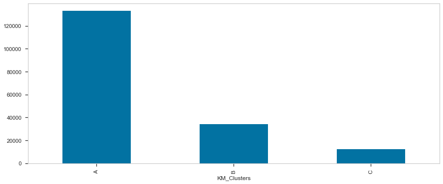

```python
# First comparing for Avg_Credit_Limit as the scale is very high compared to other fields
df.groupby('KM_Clusters')['Avg_Credit_Limit'].mean().plot.bar(figsize=(15,6))
```

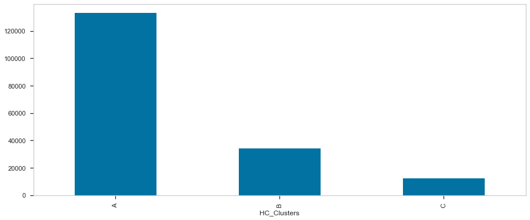

```python
df.groupby('HC_Clusters')['Avg_Credit_Limit'].mean().plot.bar(figsize=(15,6))
```

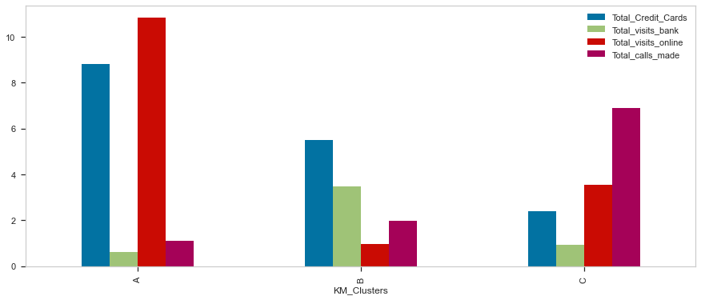

```python
df.groupby('KM_Clusters')['Total_Credit_Cards','Total_visits_bank','Total_visits_online','Total_calls_made'].mean().plot.bar(figsize=(15,6))
```

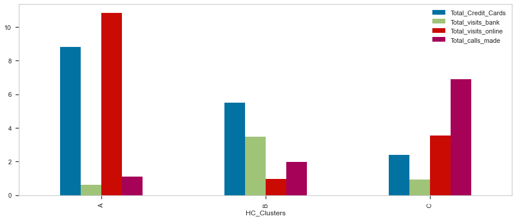

```python
df.groupby('HC_Clusters')['Total_Credit_Cards','Total_visits_bank','Total_visits_online','Total_calls_made'].mean().plot.bar(figsize=(15,6))
```

## Drawing the box plots for K means and hierarchial Clustering

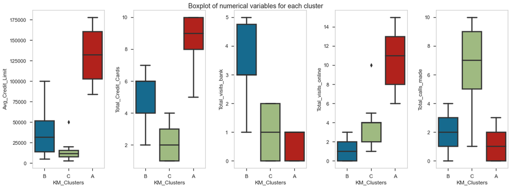

```python
fig, axes = plt.subplots(1, 5,  figsize=(16, 6))
fig.suptitle('Boxplot of numerical variables for each cluster')
counter = 0
for ii in range(5):
    sns.boxplot(ax=axes[ii],y=df[cols[counter]],x=df['KM_Clusters'])
    counter = counter+1

fig.tight_layout(pad=2.0)
```

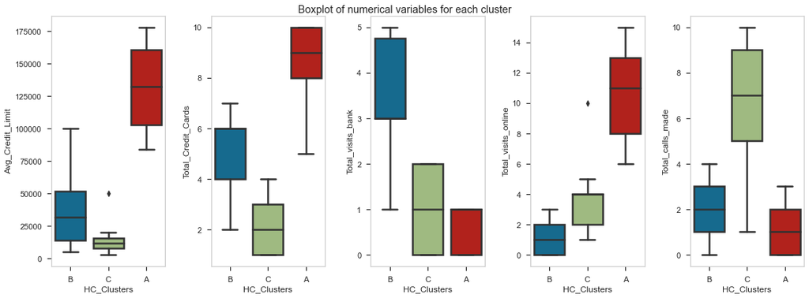

```python
fig, axes = plt.subplots(1, 5,  figsize=(16, 6))
fig.suptitle('Boxplot of numerical variables for each cluster')
counter = 0
for ii in range(5):
    sns.boxplot(ax=axes[ii],y=df[cols[counter]],x=df['HC_Clusters'])
    counter = counter+1

fig.tight_layout(pad=2.0)
```

**Insights about different clusters**

- Both the clusters have classified the same number of records in each segment
- **Segment A**
  - has maximum credit limit 178000 and minimum credit limit 84000
  - has Average credit limit of approx 133069.76
  - customers have close to 9 credit cards on an average
  - customers make between 0 to 1 visits to bank
  - customers make around 11 visits online
  - customers make around 1 call
  - has only 43 customers
- **Segment B**
  - Segment B has maximum credit limit 100000 and minimum credit limit 5000
  - Segment B has Average credit limit of approx 34071.42
  - customers have between 5 to 6 credit cards on an average
  - customers make between 3 to 4 visits to bank
  - customers make around 1 visits online
  - customers make around 2 calls
  - has maximum number of 378 customers
- **Segment C**
  - Segment C has maximum credit limit 50000 and minimum credit limit 3000
  - Segment C has Average credit limit of approx 12239.81
  - customers have between 2 to 3 credit cards on an average
  - customers make around 1 visits to bank
  - customers make between 3 to 4 visits online
  - customers make around 7 calls
  - has 221 customers

## Recommendations

**For Marketting department**

- Segment A are highend customers. They need high credit limit.
- Segment A customers already carry around 9 credit cards so they might not mind having 1 more.So its while selling them it should be kept in mind.
- Segment B customers are the maximim in number and are middle class. So they should be targetted the most
- Segment B customers have 5-6 cards already. so they might not be willing to keep more cards. So while selling cards to them we should be able to show benefit of keeping our card. Like low interest rate or interest free for 'X' number of days
- Segment C has second highest number of customers so they should be also given lot of attention. They are from low income group
- Segment C already have 2-3 cards and given their low income they might be very reluctant to keep another card. So we should give them some offers like cash back or discounts in restaurants,groceries etc

**For Delivery department**

- Class A customers mainly prefer online banking because they dont have time to goto bank. So online user experience should be improved for such customers like maybe provide a chat service or chat bots
- Class B customers who are mainly middle class have lot of time to goto bank and also they might be technically challenged to use online services. So to improve their experience we should provide fast services like having more staff, or automatic passbook entry machines or may I help you kiosk or maybe assign a dedicated mobile staff who can help them out in filling forms etc
- Class C customers prefer to do banking on phone as they might not have conveyance to travel to their nearest branch frequently and they might be technically challenged to use online services.Possibility are they are old people with low income. TO improve their phone experience we can provide IVR service in their own mothertongue language. Also need to provide less options so that they dont get confused which button to press. Also to ensure low wait time we need to deploy more customer service representatives.